# Functional Metagenome Quality Control and Normalization

Published

18 Sep 2026

This script is a modified version of Margauxs script avilable at:  
`/Volumes/home/Groups/Kristina Broliden Group (0e9ceeed)/HIV group/Margaux/R scripts metagenomics + imaging/Swabs_functional/src/Swabs_functional.qmd`  
I have extracted the normalzation and filtering part and then added the clr transform.

## Analysis workflow (step‑by‑step)

1. Load functional pathabundance file and sample metadata
2. Data format information
3. QC inspection of RPK values
4. Split into community and taxa level tables
5. Normalize to relative abundance from RPK
6. Filter pathways < 0.005% relative abundance in at least 10 samples
7. CLR transformation
8. Save normalized filtered objects
9. Plot all candida expressed pathways

### Functional annotation swab samples

This script performs QC, filtering and normalization of data generated by HUMAnN3 and MetaPhlAn functional pathway annotation of vaginal swab samples as part of the RVVC project. By shotgun sequencing all DNA present in a sample was broken in pieces and individually sequenced, followed by assembly of broken pices based on overlapping sequences to construct the DNA sequence. In the analysis pipeline host reads are removed and quality control is performed. The microbial reads are mapped to a database to determine what the detected gene’s function is.

## 1. Load data and libraries

```r
##################
# LOAD LIBRARIES #
##################
library(tidyverse)
library(mixOmics)

select <- dplyr::select
map <- purrr::map
# setwd("/Users/vilkal/work/Brolidens_work/Projects/Candida-omics/src")

#########
# PATHS #
#########
input_dir <- "../Tidy_data/Metagenomics/Functional/"
comb_meta_path <- "../Results/Combined_gr_meta_data.csv"

#############
# LOAD DATA #
#############
data <- read_csv(paste0(input_dir, "Functional_annotation_all_vagswab.csv"))

# meta data
meta <- read_csv(comb_meta_path) %>%
  mutate(across(2:26, ~ factor(.x)))
```

## 2. Understanding the data

The `pathabundance.tsv` file is one of the main outputs of HUMAnN and reports the **abundance of metabolic pathways** in a microbial community. Values are given in **RPK** (Reads Per Kilobase) units, which approximate the relative copy number of each pathway in the sample.

### Table structure

- The first column (`# Pathway`) contains pathway identifiers and special feature labels.
- The remaining columns correspond to samples (one column per sample).
- Each row represents either:
  - a **pathway**, or
  - a **special category** (e.g. `UNMAPPED`, `UNINTEGRATED`).

### Special rows

#### `UNMAPPED`

- Represents reads that **could not be aligned to any known gene family**.
- These reads are not assigned to any function and remain completely unannotated.

#### `UNINTEGRATED`

- Represents reads that **mapped to gene families but could not be assigned to any pathway**.
- This typically occurs because many genes are **not part of annotated metabolic pathways** (e.g. missing MetaCyc annotations).

##### In short:

- `UNMAPPED` = no functional assignment at all
- `UNINTEGRATED` = gene identified, but no pathway assignment

### Format of the `# Pathway` column

Bellow you see example of all 5 different formats of the `# Pathway` column that the file should contain:

```
# Pathway                                                                   demo_Abundance
UNMAPPED                                                                    9520.1365299060
UNINTEGRATED                                                                4236.5362970855
UNINTEGRATED|unclassified                                                   54.1292645042
PWY-5423: oleoresin monoterpene volatiles biosynthesis                      18.3746362785
PWY-5423: oleoresin monoterpene volatiles biosynthesis|unclassified         18.3746362785
PWY-4203: volatile benzenoid biosynthesis I (ester formation)               13.3772872602
PWY-4203: volatile benzenoid biosynthesis I (ester formation)|unclassified  13.3772872602
```

The `# Pathway` column contains two types of entries:

#### 1. Unstratified (community-level)

##### PWY-XXXX: pathway name

- Represents the total abundance of a pathway **across the entire community**.
- No taxonomic information is included.

#### 2. Stratified (taxon-specific)

##### PWY-XXXX: pathway name|g__Genus.s__Species

- The `|` (pipe) separates the pathway identifier from the contributing taxon and
- Represents the **contribution of a specific organism** to that pathway.

##### Example:

PWY-4203: volatile benzenoid biosynthesis|unclassified  
PWY-4203: volatile benzenoid biosynthesis|g__Bacteroides.s__Bacteroides_fragilis

### Key concept: stratification

HUMAnN reports pathway abundances at two levels:

- **Community level (unstratified)**  
  → total pathway abundance across all organisms
- **Stratified level (taxon-resolved)**  
  → contribution of individual taxa to each pathway

This allows analysis of both:  
- overall functional potential, and  
- species-specific functional contributions within the microbiome.

## 3. QC inspection

```r
data[c(1:2, 41, 122, 123, 129), c("# Pathway", "neg_ex_1", "S60")]
```

```
# A tibble: 6 × 3
  `# Pathway`                                                    neg_ex_1    S60
  <chr>                                                             <dbl>  <dbl>
1 UNMAPPED                                                         260851 1.71e5
2 UNINTEGRATED                                                     738747 7.71e5
3 UNINTEGRATED|g__Gardnerella.s__Gardnerella_vaginalis                  0 5.44e5
4 UNINTEGRATED|unclassified                                        738747 3.90e4
5 1CMET2-PWY: folate transformations III (E. coli)                      0 1.42e2
6 1CMET2-PWY: folate transformations III (E. coli)|g__Prevotell…        0 4.64e1
```

```r
# total RPK per sample
d <- data[, 2:ncol(data)] %>% colSums() %>% enframe() %>% arrange(value)

# control samples:
d %>%
  filter((grepl("ex|seq", .$name)))
```

```
# A tibble: 10 × 2
   name              value
   <chr>             <dbl>
 1 neg_ex_2             0
 2 neg_ex               0
 3 neg_seq_2            0
 4 neg_seq_1      1388356.
 5 zymomock_seq_2 1705645.
 6 zymomock_ex    1707060.
 7 zymomock_ex_1  1708366.
 8 zymomock_seq_1 1710298.
 9 zymomock_ex_2  1714798.
10 neg_ex_1       1739147.
```

```r
# samples
d <- d %>%
  filter(!(grepl("ex|seq", .$name)))
d
```

```
# A tibble: 159 × 2
   name      value
   <chr>     <dbl>
 1 S10    1000000.
 2 S82_1W 1025161.
 3 S71_1W 1044272.
 4 S90_1W 1062072.
 5 S74_1W 1131597.
 6 S13    1196176.
 7 S49    1219496.
 8 S32    1241111.
 9 S78_BL 1243023.
10 S74_6M 1255426.
# ℹ 149 more rows
```

```r
summary(d$value)
```

```
   Min. 1st Qu.  Median    Mean 3rd Qu.    Max.
1000000 1430478 1664940 1718080 1912299 3887600
```

Negative (DNA/RNA shield) and positive (zymomock) control samples were included in the shotgun sequencing.

## 4. Split into community and taxa level tables

The HUMAnN output table `pathabundance.tsv` is in the form of Reads Per Kilobase (RPK) normalized raw read counts (counts of reads mapped to each pathway). Meaning the raw read counts have been normalized by gene lenght. The RPK values can further be normalized to Counts per Million (CPM) or relative abundance by summing either:

1. **Taxa level:** `UNMAPPED` reads, `UNINTEGRATED |` organism-specific features, and organism-specific (i.e. pipe-containing) pathways, or
2. **Community level:**`UNMAPPED` reads, total `UNINTEGRATED` features, and pathways that are not broken down per organism.

This is nessecary in order to facilitate comparisons between samples with different sequencing depths.

Here it is described in the tutorial of Human, the two ways in witch you should normalize the pathabundance data:  
https://github.com/biobakery/biobakery/wiki/humann3#demo_pathabundancetsv

### Key rule

Do **not mix stratified and unstratified rows** in the same normalization, as this leads to incorrect totals and double counting.

```r
# rename first column name
RPK_path <- data %>%
  rename(Pathway = "# Pathway") %>%
  select(
    Pathway,
    contains("ex"),
    contains("seq"),
    sort(colnames(.)[10:ncol(.)])
  )


# select the data at:
# community level
community_lvl <- RPK_path %>%
  filter(
    Pathway == "UNMAPPED" |
      Pathway == "UNINTEGRATED" |
      !str_detect(Pathway, "\\|")
  )
community_lvl
```

```
# A tibble: 524 × 170
   Pathway      neg_ex_1 neg_ex_2 zymomock_ex_1 zymomock_ex_2 neg_ex zymomock_ex
   <chr>           <dbl>    <dbl>         <dbl>         <dbl>  <dbl>       <dbl>
 1 UNMAPPED       260851        0      86732.        85181         0    90449.
 2 UNINTEGRATED   738747        0     828972        829183         0   828495
 3 1CMET2-PWY:…        0        0        288.          295.        0      272.
 4 3-HYDROXYPH…        0        0         27.5          29.9       0       25.3
 5 4-HYDROXYMA…        0        0          3.47          3.37      0        2.92
 6 AEROBACTINS…        0        0         39.2          43.9       0       34.0
 7 ALLANTOINDE…        0        0         22.3          26.8       0       23.0
 8 ANAEROFRUCA…        0        0        354.          356.        0      337.
 9 ANAGLYCOLYS…        0        0        407.          398.        0      391.
10 ARG+POLYAMI…        0        0        233.          244.        0      218.
# ℹ 514 more rows
# ℹ 163 more variables: neg_seq_1 <dbl>, neg_seq_2 <dbl>, zymomock_seq_1 <dbl>,
#   zymomock_seq_2 <dbl>, KX63 <dbl>, KX64 <dbl>, S01 <dbl>, S02 <dbl>,
#   S03 <dbl>, S04 <dbl>, S05 <dbl>, S06 <dbl>, S07 <dbl>, S08 <dbl>,
#   S09 <dbl>, S10 <dbl>, S11 <dbl>, S12 <dbl>, S13 <dbl>, S14 <dbl>,
#   S15 <dbl>, S16 <dbl>, S17 <dbl>, S18 <dbl>, S19 <dbl>, S20 <dbl>,
#   S21 <dbl>, S22 <dbl>, S23 <dbl>, S24 <dbl>, S25 <dbl>, S26 <dbl>, …
```

```r
# taxa level (stratified)
taxa_lvl <- RPK_path %>%
  filter(
    Pathway == "UNMAPPED" |
      str_detect(Pathway, "\\|")
  )
taxa_lvl
```

```
# A tibble: 6,312 × 170
   Pathway      neg_ex_1 neg_ex_2 zymomock_ex_1 zymomock_ex_2 neg_ex zymomock_ex
   <chr>           <dbl>    <dbl>         <dbl>         <dbl>  <dbl>       <dbl>
 1 UNMAPPED       260851        0        86732.         85181      0      90449.
 2 UNINTEGRATE…        0        0            0              0      0          0
 3 UNINTEGRATE…        0        0            0              0      0          0
 4 UNINTEGRATE…        0        0            0              0      0          0
 5 UNINTEGRATE…        0        0            0              0      0          0
 6 UNINTEGRATE…        0        0            0              0      0          0
 7 UNINTEGRATE…        0        0            0              0      0          0
 8 UNINTEGRATE…        0        0            0              0      0          0
 9 UNINTEGRATE…        0        0            0              0      0          0
10 UNINTEGRATE…        0        0            0              0      0          0
# ℹ 6,302 more rows
# ℹ 163 more variables: neg_seq_1 <dbl>, neg_seq_2 <dbl>, zymomock_seq_1 <dbl>,
#   zymomock_seq_2 <dbl>, KX63 <dbl>, KX64 <dbl>, S01 <dbl>, S02 <dbl>,
#   S03 <dbl>, S04 <dbl>, S05 <dbl>, S06 <dbl>, S07 <dbl>, S08 <dbl>,
#   S09 <dbl>, S10 <dbl>, S11 <dbl>, S12 <dbl>, S13 <dbl>, S14 <dbl>,
#   S15 <dbl>, S16 <dbl>, S17 <dbl>, S18 <dbl>, S19 <dbl>, S20 <dbl>,
#   S21 <dbl>, S22 <dbl>, S23 <dbl>, S24 <dbl>, S25 <dbl>, S26 <dbl>, …
```

## 5. Normalize to relative abundance from RPK

When normalizing pathway abundance tables (`pathabundance.tsv`), HUMAnN uses two alternative strategies depending on whether you work at the **community level** or **organism-stratified level**.

### 1. Stratified (organism-specific) normalization

Use this when working with rows that include taxonomic stratification (`|`).

##### Include in total sum:

- `UNMAPPED`
- All `UNINTEGRATED|...` rows (stratified only)
- All pathway rows with `|` (e.g. `PWY-XXXX|taxon`)

##### Exclude:

- `UNINTEGRATED` (unstratified total)
- Unstratified pathway rows (no `|`)

→ This gives relative abundances at the **organism-specific level**.

### 2. Unstratified (community-level) normalization

Use this when working with aggregated (non-stratified) data.

##### Include in total sum:

- `UNMAPPED`
- `UNINTEGRATED` (single total row)
- All pathway rows without `|`

##### Exclude:

- All stratified rows (`|`), including:
  - `UNINTEGRATED|...`
  - `PWY-XXXX|...`

→ This gives relative abundances at the **community level**.

**NB!** even though proportions and percentages are the exact same mathematical value (e.g., (0.05) is (5%)), using proportions is the universal best practice for statistical calculations, data normalization (Total Sum Scaling), and downstream analyses. Percentages are best reserved for final data visualization and layman communication.

```r
# path abundance/total path abundance per sample creates the relative path abundance (in percentage)
relative_path <- list(
  "community_lvl" = community_lvl,
  "taxa_lvl" = taxa_lvl
) %>%
  map(
    ~ .x %>%
      mutate(across(where(is.numeric), ~ . / sum(.)))
  )

# check the relative abundance per participant sums to 1
relative_path %>%
  map(
    ~ .x %>%
      #bind_rows(
      summarise(
        .,
        Pathway = "Total",
        across(where(is.numeric), sum)
      ) %>%
      pivot_longer(-Pathway) %>%
      filter(value < 99 | is.na(value))
  )
```

```
$community_lvl
# A tibble: 169 × 3
   Pathway name           value
   <chr>   <chr>          <dbl>
 1 Total   neg_ex_1           1
 2 Total   neg_ex_2         NaN
 3 Total   zymomock_ex_1      1
 4 Total   zymomock_ex_2      1
 5 Total   neg_ex           NaN
 6 Total   zymomock_ex        1
 7 Total   neg_seq_1          1
 8 Total   neg_seq_2        NaN
 9 Total   zymomock_seq_1     1
10 Total   zymomock_seq_2     1
# ℹ 159 more rows

$taxa_lvl
# A tibble: 169 × 3
   Pathway name           value
   <chr>   <chr>          <dbl>
 1 Total   neg_ex_1           1
 2 Total   neg_ex_2         NaN
 3 Total   zymomock_ex_1      1
 4 Total   zymomock_ex_2      1
 5 Total   neg_ex           NaN
 6 Total   zymomock_ex        1
 7 Total   neg_seq_1          1
 8 Total   neg_seq_2        NaN
 9 Total   zymomock_seq_1     1
10 Total   zymomock_seq_2     1
# ℹ 159 more rows
```

```r
# Fix na values
relative_path <- relative_path %>%
  map(
    ~ .x %>%
      mutate(across(where(is.numeric), ~ replace_na(.x, 0)))
  )

comb_relative_path <- relative_path %>%
  bind_rows(., .id = "level") %>%
  #mutate(S10 = replace_na(S10, 0)) %>%
  filter(Pathway != "Total")

#save this in a new data file
write_csv(
  comb_relative_path,
  paste0(input_dir, "Functional_annotation_all_vagswab_relative_abundance.csv")
)
```

Note to self: The original code from Margaux did the selection for the community level dataframe correctly. However, I added code to also normalize at the stratified (taxa level), but I did not add the UNMAPPED reads, that should have been included to get the correct percentages. This is fine since I have not used the taxa level data so fare and now it will be corrected.

**NB!** Sample S10 has Zero abundance at taxa level even though at pathway level it has a a low abundance of pathway:  
PWY-6124: inosine-5’-phosphate biosynthesis II  
PWY-6123: inosine-5’-phosphate biosynthesis I

## 6. Filter pathways < 0.005% relative abundance in at least 10 samples

### remove control samples

```r
relative_path <- relative_path %>%
  map(
    ~ .x %>%
      select(
        -contains("ex"),
        -contains("seq"),
        -contains("run2"),
        -contains("KX")
      )
  )

# before taxa filtering we select the MOFA selected samples
m <- read_csv("../Results/Sample_omic_table.csv")
relative_path <- relative_path %>%
  map(
    ~ .x %>%
      select(
        Pathway,
        any_of(m$sample[m$at_least_two & m$all_BL])
      )
  )

n_samples <- select(relative_path[[1]], starts_with("S")) %>% ncol() # number of good samples
n_samples
```

```
[1] 88
```

### Identify pathways with very low relative abundance

To remove very low abundant taxa or functional pathways, pathways with less than 0.005% relative abundance in at least 10 samples are removed. Because we are using proportions, not percentages we have to divide this by 100 when performing the filtering.

```r
# Pathways that have 0% relative abundance for all samples minus controls and run2
null_pathways <- relative_path$community_lvl %>%
  filter(if_all(-Pathway, ~ . == 0))

null_pathways %>%
  mutate(rowsum = rowSums(across(-Pathway)), .after = "Pathway") %>%
  arrange(desc(rowsum))
```

```
# A tibble: 120 × 90
   Pathway    rowsum   S01   S02   S03   S04   S05   S06   S07   S08   S09   S10
   <chr>       <dbl> <dbl> <dbl> <dbl> <dbl> <dbl> <dbl> <dbl> <dbl> <dbl> <dbl>
 1 3-HYDROXY…      0     0     0     0     0     0     0     0     0     0     0
 2 4-HYDROXY…      0     0     0     0     0     0     0     0     0     0     0
 3 AEROBACTI…      0     0     0     0     0     0     0     0     0     0     0
 4 ALLANTOIN…      0     0     0     0     0     0     0     0     0     0     0
 5 ARGDEG-PW…      0     0     0     0     0     0     0     0     0     0     0
 6 ECASYN-PW…      0     0     0     0     0     0     0     0     0     0     0
 7 ERGOSTERO…      0     0     0     0     0     0     0     0     0     0     0
 8 HCAMHPDEG…      0     0     0     0     0     0     0     0     0     0     0
 9 LEU-DEG2-…      0     0     0     0     0     0     0     0     0     0     0
10 LIPA-CORE…      0     0     0     0     0     0     0     0     0     0     0
# ℹ 110 more rows
# ℹ 78 more variables: S11 <dbl>, S12 <dbl>, S13 <dbl>, S15 <dbl>, S17 <dbl>,
#   S18 <dbl>, S19 <dbl>, S20 <dbl>, S22 <dbl>, S23 <dbl>, S25 <dbl>,
#   S26 <dbl>, S27 <dbl>, S29 <dbl>, S30 <dbl>, S34 <dbl>, S35 <dbl>,
#   S36 <dbl>, S37 <dbl>, S38 <dbl>, S39 <dbl>, S40 <dbl>, S41 <dbl>,
#   S42 <dbl>, S43 <dbl>, S44 <dbl>, S45 <dbl>, S46 <dbl>, S47 <dbl>,
#   S48 <dbl>, S49 <dbl>, S50 <dbl>, S51 <dbl>, S52 <dbl>, S53 <dbl>, …
```

```r
community_lvl <- relative_path$community_lvl %>%
  filter(if_any(-Pathway, ~ . != 0))
community_lvl
```

```
# A tibble: 404 × 89
   Pathway           S01     S02     S03     S04     S05     S06     S07     S08
   <chr>           <dbl>   <dbl>   <dbl>   <dbl>   <dbl>   <dbl>   <dbl>   <dbl>
 1 UNMAPPED      4.72e-1 3.17e-1 3.35e-1 4.25e-1 5.08e-1 6.50e-1 5.79e-1 7.36e-1
 2 UNINTEGRATED  5.11e-1 6.56e-1 6.50e-1 5.54e-1 4.74e-1 3.39e-1 4.08e-1 2.55e-1
 3 1CMET2-PWY: … 0       1.36e-5 0       0       0       0       0       0
 4 ANAEROFRUCAT… 4.01e-5 5.24e-5 3.93e-6 5.02e-6 2.08e-6 0       0       0
 5 ANAGLYCOLYSI… 7.00e-5 8.16e-5 6.56e-6 8.70e-6 2.74e-5 2.90e-6 1.50e-6 1.98e-6
 6 ARG+POLYAMIN… 0       0       0       0       0       0       0       0
 7 ARGININE-SYN… 0       3.11e-6 0       0       0       2.45e-6 0       0
 8 ARGSYN-PWY: … 0       3.50e-6 0       0       4.21e-6 0       0       0
 9 ARGSYNBSUB-P… 0       3.72e-6 0       0       5.29e-6 0       0       0
10 ARO-PWY: cho… 1.41e-5 1.42e-5 2.29e-6 0       2.44e-6 3.52e-6 0       3.54e-5
# ℹ 394 more rows
# ℹ 80 more variables: S09 <dbl>, S10 <dbl>, S11 <dbl>, S12 <dbl>, S13 <dbl>,
#   S15 <dbl>, S17 <dbl>, S18 <dbl>, S19 <dbl>, S20 <dbl>, S22 <dbl>,
#   S23 <dbl>, S25 <dbl>, S26 <dbl>, S27 <dbl>, S29 <dbl>, S30 <dbl>,
#   S34 <dbl>, S35 <dbl>, S36 <dbl>, S37 <dbl>, S38 <dbl>, S39 <dbl>,
#   S40 <dbl>, S41 <dbl>, S42 <dbl>, S43 <dbl>, S44 <dbl>, S45 <dbl>,
#   S46 <dbl>, S47 <dbl>, S48 <dbl>, S49 <dbl>, S50 <dbl>, S51 <dbl>, …
```

There are 120 pathways that had so low abundance that they can be concidered zero in all samples.  
This resulted in 404 pathways for further filtering by filtering criteria

```r
# pathways with <0.005% relative abundance in at least 10 samples
threshold <- 0.005 / 100 # 0.00005
min_samples <- 10
low_pathways <- community_lvl %>%
  mutate(rowsum = rowSums(across(-Pathway)), .after = "Pathway") %>%
  mutate(
    n = rowSums(across(-Pathway, ~ . >= threshold)),
    .after = "Pathway"
  ) %>%
  filter(rowSums(across(-Pathway, ~ . >= threshold)) < min_samples)

low_pathways[, 1:3]
```

```
# A tibble: 289 × 3
   Pathway                                                             n  rowsum
   <chr>                                                           <dbl>   <dbl>
 1 1CMET2-PWY: folate transformations III (E. coli)                    4 3.14e-4
 2 ARG+POLYAMINE-SYN: superpathway of arginine and polyamine bios…     0 3.24e-5
 3 ARGININE-SYN4-PWY: L-ornithine biosynthesis II                      1 1.44e-4
 4 ARGSYN-PWY: L-arginine biosynthesis I (via L-ornithine)             6 6.08e-4
 5 ARGSYNBSUB-PWY: L-arginine biosynthesis II (acetyl cycle)           5 5.97e-4
 6 AST-PWY: L-arginine degradation II (AST pathway)                    0 9.73e-6
 7 BIOTIN-BIOSYNTHESIS-PWY: biotin biosynthesis I                      0 3.39e-5
 8 CARNMET-PWY: L-carnitine degradation I                              0 2.64e-6
 9 CATECHOL-ORTHO-CLEAVAGE-PWY: catechol degradation to &beta;-ke…     0 1.10e-5
10 CENTFERM-PWY: pyruvate fermentation to butanoate                    0 9.91e-7
# ℹ 279 more rows
```

A furter 289 pathways failed the filtering criteria (more than 0.005% relative abundance in at least 10 samples) resulting in 109 pathways (including UNMAPPED and UNINTEGRATED)

```r
# remove low abundant pathways from data file
community_lvl <- community_lvl %>%
  filter(rowSums(across(-Pathway, ~ . >= threshold)) >= min_samples)
community_lvl
```

```
# A tibble: 109 × 89
   Pathway           S01     S02     S03     S04     S05     S06     S07     S08
   <chr>           <dbl>   <dbl>   <dbl>   <dbl>   <dbl>   <dbl>   <dbl>   <dbl>
 1 UNMAPPED      4.72e-1 3.17e-1 3.35e-1 4.25e-1 5.08e-1 6.50e-1 5.79e-1 7.36e-1
 2 UNINTEGRATED  5.11e-1 6.56e-1 6.50e-1 5.54e-1 4.74e-1 3.39e-1 4.08e-1 2.55e-1
 3 ANAEROFRUCAT… 4.01e-5 5.24e-5 3.93e-6 5.02e-6 2.08e-6 0       0       0
 4 ANAGLYCOLYSI… 7.00e-5 8.16e-5 6.56e-6 8.70e-6 2.74e-5 2.90e-6 1.50e-6 1.98e-6
 5 ARO-PWY: cho… 1.41e-5 1.42e-5 2.29e-6 0       2.44e-6 3.52e-6 0       3.54e-5
 6 ASPASN-PWY: … 2.13e-5 2.21e-5 4.40e-6 0       1.84e-6 1.76e-6 1.74e-6 0
 7 BRANCHED-CHA… 0       0       0       0       4.30e-6 0       0       0
 8 CALVIN-PWY: … 3.06e-5 4.94e-5 0       2.25e-6 0       0       0       0
 9 COA-PWY-1: s… 5.79e-4 9.07e-4 6.49e-4 6.89e-4 5.49e-4 3.51e-4 4.33e-4 1.52e-4
10 COA-PWY: coe… 5.24e-4 8.27e-4 5.79e-4 6.46e-4 6.66e-4 3.49e-4 4.40e-4 3.59e-4
# ℹ 99 more rows
# ℹ 80 more variables: S09 <dbl>, S10 <dbl>, S11 <dbl>, S12 <dbl>, S13 <dbl>,
#   S15 <dbl>, S17 <dbl>, S18 <dbl>, S19 <dbl>, S20 <dbl>, S22 <dbl>,
#   S23 <dbl>, S25 <dbl>, S26 <dbl>, S27 <dbl>, S29 <dbl>, S30 <dbl>,
#   S34 <dbl>, S35 <dbl>, S36 <dbl>, S37 <dbl>, S38 <dbl>, S39 <dbl>,
#   S40 <dbl>, S41 <dbl>, S42 <dbl>, S43 <dbl>, S44 <dbl>, S45 <dbl>,
#   S46 <dbl>, S47 <dbl>, S48 <dbl>, S49 <dbl>, S50 <dbl>, S51 <dbl>, …
```

```r
# filter taxa level
# by removing the same pathways as identified as low at community level
taxa_lvl <- relative_path$taxa_lvl %>%
  filter(grepl(paste0(community_lvl$Pathway, collapse = "|"), .$Pathway))
taxa_lvl
```

```
# A tibble: 2,835 × 89
   Pathway     S01   S02   S03   S04   S05   S06   S07   S08     S09   S10   S11
   <chr>     <dbl> <dbl> <dbl> <dbl> <dbl> <dbl> <dbl> <dbl>   <dbl> <dbl> <dbl>
 1 UNMAPPED  0.396 0.248 0.250 0.344 0.442 0.601 0.575 0.701 0.341       1 0.286
 2 UNINTEGR… 0     0     0     0     0     0     0     0     0           0 0
 3 UNINTEGR… 0     0     0     0     0     0     0     0     0           0 0
 4 UNINTEGR… 0     0     0     0     0     0     0     0     0           0 0
 5 UNINTEGR… 0     0     0     0     0     0     0     0     0           0 0
 6 UNINTEGR… 0     0     0     0     0     0     0     0     0           0 0
 7 UNINTEGR… 0     0     0     0     0     0     0     0     0.00525     0 0
 8 UNINTEGR… 0     0     0     0     0     0     0     0     0           0 0
 9 UNINTEGR… 0     0     0     0     0     0     0     0     0           0 0
10 UNINTEGR… 0     0     0     0     0     0     0     0     0           0 0
# ℹ 2,825 more rows
# ℹ 77 more variables: S12 <dbl>, S13 <dbl>, S15 <dbl>, S17 <dbl>, S18 <dbl>,
#   S19 <dbl>, S20 <dbl>, S22 <dbl>, S23 <dbl>, S25 <dbl>, S26 <dbl>,
#   S27 <dbl>, S29 <dbl>, S30 <dbl>, S34 <dbl>, S35 <dbl>, S36 <dbl>,
#   S37 <dbl>, S38 <dbl>, S39 <dbl>, S40 <dbl>, S41 <dbl>, S42 <dbl>,
#   S43 <dbl>, S44 <dbl>, S45 <dbl>, S46 <dbl>, S47 <dbl>, S48 <dbl>,
#   S49 <dbl>, S50 <dbl>, S51 <dbl>, S52 <dbl>, S53 <dbl>, S54 <dbl>, …
```

```r
# re-normalize composition to sum to 1 (IMPORTANT) and combine
comb_relative_path <- list(community_lvl, taxa_lvl) %>%
  set_names(., c("community_lvl", "taxa_lvl")) %>%
  map(., ~ mutate(.x, across(where(is.numeric), ~ . / sum(.)))) %>%
  bind_rows(., .id = "level")


# check the relative abundance per participant sums to 1
comb_relative_path %>%
  filter(level != "community_lvl") %>%
  summarise(
    .,
    #Pathway = "Total",
    across(where(is.numeric), sum)
  ) %>%
  pivot_longer(everything()) #%>%
```

```
# A tibble: 88 × 2
   name  value
   <chr> <dbl>
 1 S01       1
 2 S02       1
 3 S03       1
 4 S04       1
 5 S05       1
 6 S06       1
 7 S07       1
 8 S08       1
 9 S09       1
10 S10       1
# ℹ 78 more rows
```

```r
#filter(value < 1 | is.na(value))

comb_relative_path %>%
  filter(level != "taxa_lvl") %>%
  summarise(
    .,
    across(where(is.numeric), sum)
  ) %>%
  pivot_longer(everything())
```

```
# A tibble: 88 × 2
   name  value
   <chr> <dbl>
 1 S01       1
 2 S02       1
 3 S03       1
 4 S04       1
 5 S05       1
 6 S06       1
 7 S07       1
 8 S08       1
 9 S09       1
10 S10       1
# ℹ 78 more rows
```

```r
# write_csv(comb_relative_path, paste0(input_dir, "Functional_annotation_relative_abundance_filtered.csv"))
# comb_relative_path <- read_csv("../Tidy_data/Metagenomics/Functional/Functional_annotation_relative_abundance_filtered.csv")
```

120 identified pathways had no relative abundance across all samples and were removed. This means 404 pathways remain in the relative abundance data frame after their removal. Next, filtering based on the pathways relative abundance (more than 0.005% relative abundance in at least 10 samples) removed 289 low abundant pathways from the data frame, leaving 109 pathways of interest (including UNMAPPED and UNINTEGRATED).

Summary table low pathways (sum per pathway), set a cut off below 1%

## 7. CLR transformation

### CLR Transformation: Assumptions and Preprocessing

The centered log-ratio (CLR) transform requires **compositional data**, where each sample contains non-negative values that sum to a constant (e.g. proportions).

##### Before applying CLR:

- Filter low-abundance features
- Remove non-informative features (e.g. `UNMAPPED`, `UNINTEGRATED`)
- Re-normalize after filtering out non-informative features
- Normalize to proportions (sum = 1 per sample)
- Handle zeros and missing values:
  - replace `NA` with 0
  - use a small pseudocount (e.g. `1e-6`) during transformation
- Remove all-zero features (rowsum = 0)
- Ensure no sample has a total of 0 (colsum = 0)
- transpose matrix (clr function expects samples x rows)

```r
rel_path_dfs <- list("community_lvl" = community_lvl, "taxa_lvl" = taxa_lvl)

# clr transform for pathways and taxa level
rel_path_clr <- rel_path_dfs %>%
  map(
    ~ .x %>%
      filter(!(grepl("UNINTEGRATED", .$`Pathway`))) %>%
      column_to_rownames(., "Pathway") %>%
      logratio.transfo(., logratio = "CLR", offset = 1)
  )

write_rds(
  rel_path_clr,
  paste0(input_dir, "Functional_annotation_CLR_filtered.RDS")
)
```

**NB!** Because sample S10 has Zero abundance at taxa level even though at pathway level it has a a low abundance of pathway: PWY-6124: inosine-5’-phosphate biosynthesis II PWY-6123: inosine-5’-phosphate biosynthesis I We will filter out S10 for both community and taxa level data, before performing CLR

**NB!** the majority of mixOmics functions expect a format of samples as rows and features as columns, thus it is VERY important to first transpose the data when applying CLR!

```r
rel_path_dfs <- list("community_lvl" = community_lvl, "taxa_lvl" = taxa_lvl)

# clr transform for pathways and taxa level
rel_path_clr <- rel_path_dfs %>%
  map(
    ~ .x %>%
      # remove S10 sample
      select(-"S10") %>%

      # remove non-informative rows
      filter(!grepl("UNINTEGRATED|UNMAPPED", Pathway)) %>%

      # move pathway names to rownames
      column_to_rownames("Pathway") %>%

      # re-normalize composition to sum to 1 (IMPORTANT)
      mutate(across(everything(), ~ . / sum(.))) %>%

      # transpose to samples (rows) x taxa (columns)
      as.matrix() %>%
      t() %>%

      # CLR transform with small pseudocount
      logratio.transfo(logratio = "CLR", offset = 1e-6)
  )
```

## 8. Save normalized filtered objects

```r
# combined long format table:
comb_relative_long <- comb_relative_path %>%
  pivot_longer(
    .,
    cols = where(is.numeric),
    names_to = "sample",
    values_to = "abundance"
  )

comb_relative_long <- rel_path_clr %>%
  #map(., ~unclass(.x) ) %>%
  map(
    ~ .x %>%
      unclass(.) %>%
      t() %>%
      as_tibble(mat, rownames = "Pathway")
  ) %>%
  bind_rows(., .id = "level") %>%
  pivot_longer(
    .,
    cols = where(is.numeric),
    names_to = "sample",
    values_to = "CLR"
  ) %>%
  left_join(comb_relative_long, ., by = c("Pathway", "level", "sample"))

# write_csv(comb_relative_long, paste0(input_dir, "Functional_abundance_CLR_filtered_long.csv"))
# comb_relative_long <- read_csv("../Tidy_data/Metagenomics/Functional/Functional_abundance_CLR_filtered_long.csv")

# CLR only, wide format:
rel_path_clr <- rel_path_clr %>%
  map(
    ~ .x %>%
      unclass(.) %>%
      t() %>%
      as_tibble(mat, rownames = "Pathway") %>%
      #filter(!(grepl("UNINTEGRATED|UNMAPPED", .$`# Pathway`))) %>%
      separate(col = "Pathway", sep = "\\|", into = c("Pathway", "taxa")) %>%
      separate(col = "Pathway", sep = ": ", into = c("short", "long")) %>%
      mutate(taxa = ifelse(is.na(taxa), "total", taxa)) %>%
      mutate(taxa = gsub("^.+s__", "", .$taxa))
  )
write_rds(
  rel_path_clr,
  paste0(input_dir, "Functional_annotation_CLR_filtered.RDS")
)

# rel_path_clr <- readRDS("../Tidy_data/Metagenomics/Functional/Functional_annotation_CLR_filtered.RDS")
```

```r
m <- read_csv("../Results/Sample_omic_table.csv")
s <- m$sample[m$at_least_two & m$all_BL]

comb_long <- comb_relative_long %>%
  separate(col = "Pathway", sep = "\\|", into = c("Pathway", "taxa")) %>%
  separate(col = "Pathway", sep = ": ", into = c("short", "long")) %>%
  mutate(taxa = ifelse(is.na(taxa), "total", taxa)) %>%
  mutate(taxa = gsub("^.+s__", "", .$taxa)) %>%

  mutate(taxa = ifelse(is.na(taxa), "unintegrated", taxa)) %>%
  mutate(species = str_replace_all(taxa, "_", " ")) %>%
  mutate(genus = str_replace(taxa, "_\\w+$", "")) %>%
  left_join(
    .,
    select(meta, 1:6, fct1_clus, `Clinical_score_(0-5)`),
    by = c("sample")
  ) %>%
  # filter samples:
  filter(sample %in% s) %>%
  filter(sample != "S10") %>%
  split(~level)
```

## 9. Plot all candida expressed pathways

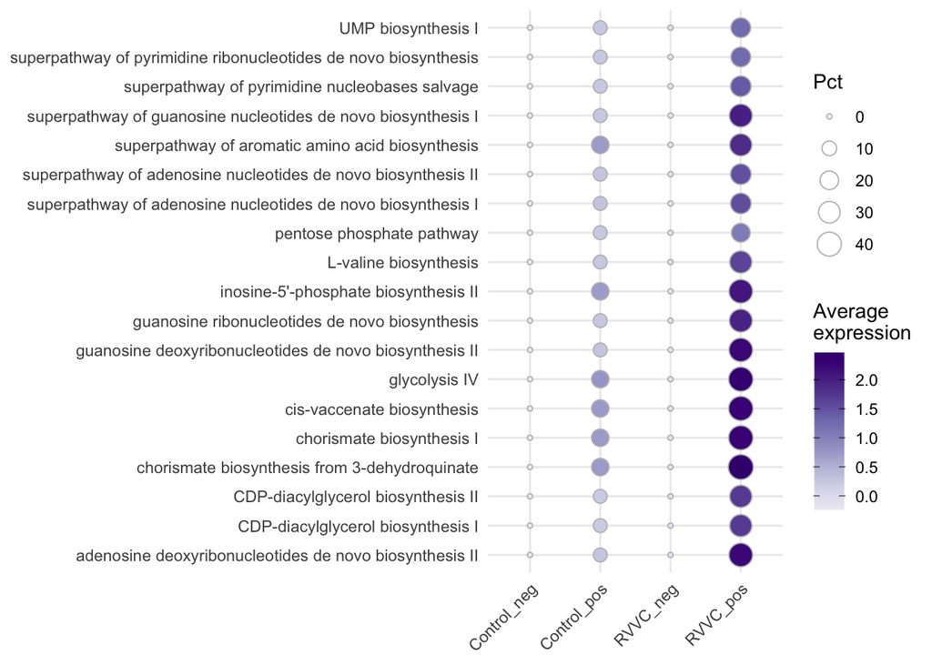

```r
# col <- brewer.pal(8, name = "Purples")
col <- c(
  "#EFEDF5",
  "#DADAEB",
  "#BCBDDC",
  "#9E9AC8",
  "#807DBA",
  "#6A51A3",
  "#54278F",
  "#3F007D"
)

# plot pathways expressed by candida
df_sum_CLR_candida <- comb_long$taxa_lvl %>%
  filter(short != "UNINTEGRATED") %>%
  filter(grepl("Candida", .$taxa)) %>%

  #mutate(groups = factor(.$Clusters, levels=names(clus_lvl))) %>%
  group_by(short, long, RVVC_pos) %>%
  filter(!(is.na(CLR))) %>%
  summarise(
    Avg = mean(CLR),
    Avg_ = mean(CLR) / max(CLR), # gives the median as a percentage of max value among spots if .5 you have a normal dist.
    Pct = sum(CLR > 0) / length(CLR) * 100,
    .groups = "drop"
  ) %>%
  #group_by(marker) %>%
  #nest()
  mutate(Avg_p = Avg / max(Avg), .by = "short")

# quartz(width = 7, height = 6) # , dpi = 150
df_sum_CLR_candida %>%
  ggplot(., aes(y = long, x = .data[["RVVC_pos"]])) +
  geom_point(aes(size = Pct, fill = Avg), col = "gray", shape = 21) + #"#6A2595"
  scale_fill_gradientn(
    colours = col,
    guide = guide_colorbar(ticks.colour = "black", frame.colour = "white"),
    name = "Average\nexpression"
  ) +
  theme_minimal() +
  theme(
    axis.title = element_blank(),
    axis.text.x = element_text(angle = 45, hjust = 1)
  )
```

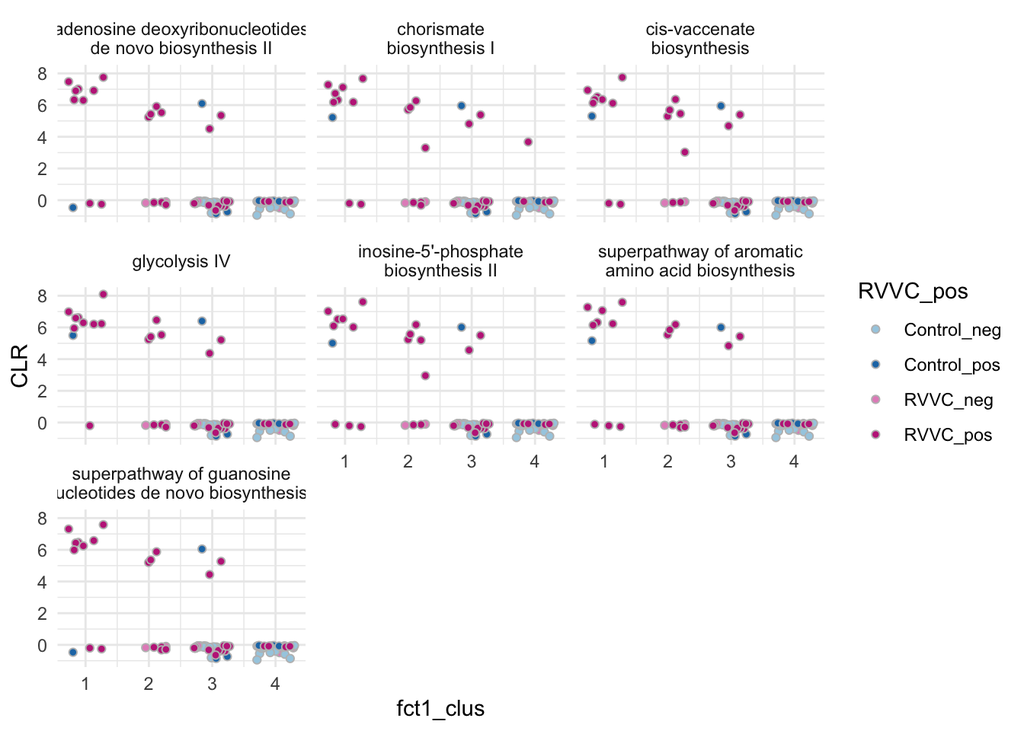

```r
# top <- weights$Functional$feature[1:20]
# comb_long$taxa_lvl %>%
#   filter(long %in% top) %>%
#   ggplot(., aes(y = CLR, x = .data[["RVVC_pos"]])) +
#   geom_point(aes(fill = CLR), col = "gray", shape = 21) +
#   facet_wrap(~long)

insert_line_break <- function(x, min_length = 15) {
  purrr::map_chr(x, \(xi) {
    if (nchar(xi) <= min_length) {
      return(xi)
    }
    sp <- stringr::str_locate_all(xi, " ")[[1]][, 1]
    if (!length(sp)) {
      return(xi)
    }
    i <- sp[which.min(abs(sp - nchar(xi) / 2))]
    paste0(substr(xi, 1, i - 1), "\n", substr(xi, i + 1, nchar(xi)))
  })
}

library(RColorBrewer)
pal <- list(
  "Clinical_score_(0-5)" = brewer.pal(6, name = "Reds") %>% set_names(., 0:5),
  RVVC_pos = c(
    "#A6CEE3",
    "#1F78B4",
    "#e490c4ff",
    "#c12d88ff"
  )
)
pat <- c(
  "glycolysis IV",
  "adenosine deoxyribonucleotides de novo biosynthesis II",
  "inosine-5'-phosphate biosynthesis II",
  "superpathway of guanosine nucleotides de novo biosynthesis I",
  "chorismate biosynthesis I",
  "superpathway of aromatic amino acid biosynthesis",
  "cis-vaccenate biosynthesis"
)

fill_val <- "Clinical_score_(0-5)"
fill_val <- "RVVC_pos"

comb_long$taxa_lvl %>%
  filter(short != "UNINTEGRATED") %>%
  filter(grepl("Candida", .$taxa)) %>%
  filter(long %in% pat) %>%

  mutate(long = insert_line_break(long)) %>%
  arrange(`Clinical_score_(0-5)`) %>%
  #filter(long == "glycolysis IV") %>%
  ggplot(., aes(y = CLR, x = .data[["fct1_clus"]])) +
  geom_jitter(
    aes(fill = .data[[fill_val]]),
    col = "gray",
    shape = 21,
    width = 0.3
  ) +
  scale_fill_manual(values = pal[[fill_val]]) +
  theme_minimal() +
  facet_wrap(~long)
```